# Predicting Hits with Decision Trees

August 23, 2019

## Index

- Working with Gradient Boosting Machine (GMB)
- Looking closer in the data set
- Cleaning up the data set
- Results after clean up
- Next steps

## Working with GMB

## What does GBM do?

- Each tree is grown using information from previous one
- After evaluating the first tree
  - increase weights of observations that are hard to classify
  - and lower the weights for those that are easy to classify
- In other words, given the current model
  - fit a tree using the current residuals
  - rather than the outcome
- This method slowly converts weak learners into strong ones

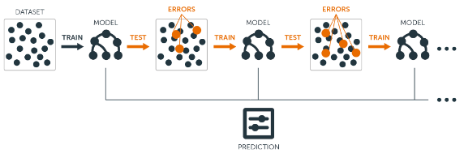

## Let's try to predict the 5th tracking hit

- Sample of 10K tracks
- Training phase
  - Inputs for GBM:
    - x_1, x_2, x_3, x_4, y_1, y_2, y_3, y_4, z_1, z_2, z_3, z_4
    - 7K tracks
    - Number of trees = 200
    - Trees shrinkage = 0.1 (10%)
    - Trees interaction depth = 10
    - GBM distribution = gaussian
- Testing phase
  - 3K tracks
  - 39 trees between 10 and 200 (in steps of 5)

## Relative influence from each input coordinate

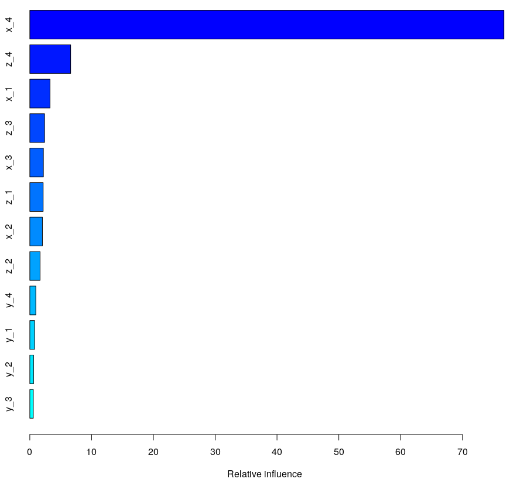

## Best number of trees for prediction (I)

- Trying to predict 5th tracking hit
- Compute Minimum Mean Squared Error for each number of tree \(n_{tree}\)
  - Considering
    - 39 trees between 10 and 200 (in steps of 5)
    - N = 3K tracks

\[MSE_{n_{tree}} = \frac{\sum_{i=1}^{N} (x^{Test}_{i} - x^{Predicted}_{i})^2}{N}\]

## Best number of trees for prediction (II)

- Minimum MSE = 3576 \(mm^2\) for 45 trees

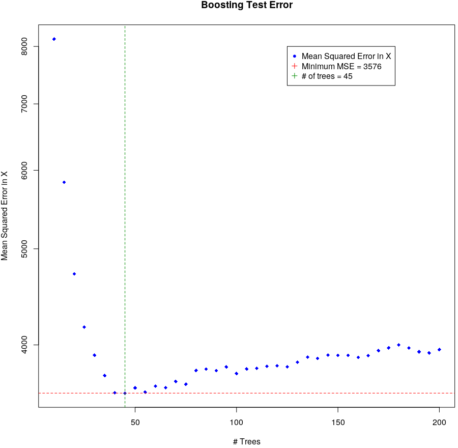

## Checking predicted results for 5th hit

- We observe a considerable fluctuation
- A dream case would be a straight diagonal line

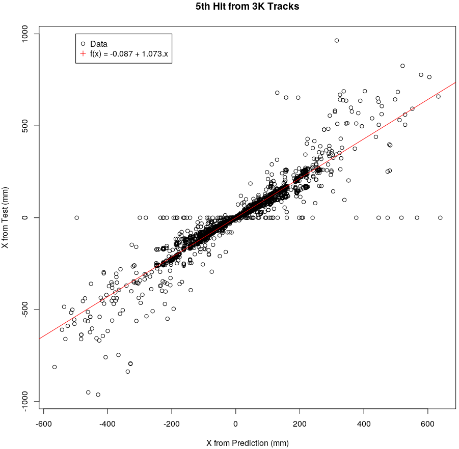

## Looking closer in the data

## Plotting all hits in X-Y plane (I)

- Hits from 10K tracks with |z| < 300 mm
- We observe an overlay of the plates

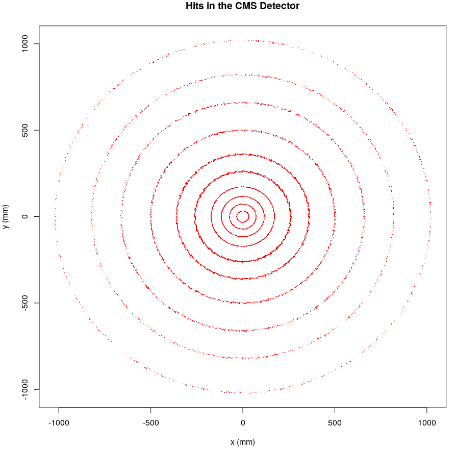

## Plotting all hits in X-Y plane (II)

- Adding a track
- Some layers have more than 1 hit

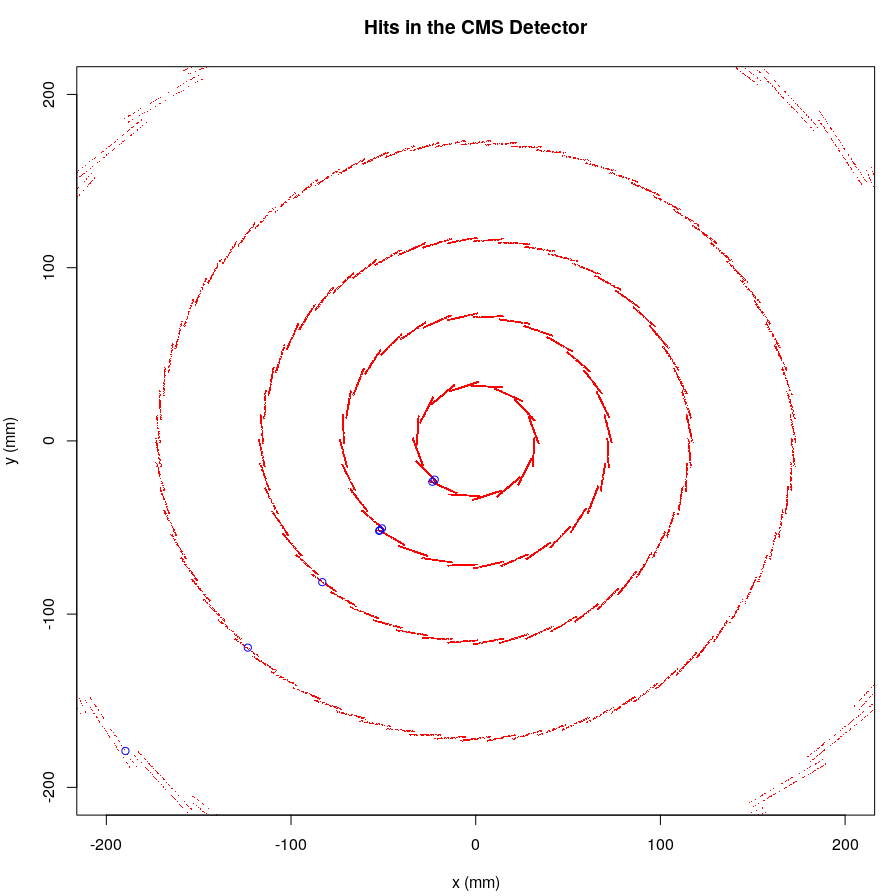

## Plotting all hits in X-Y plane (III)

- If we try to predict the 5th hit using previous 4
  - It could bring difficult to GBM

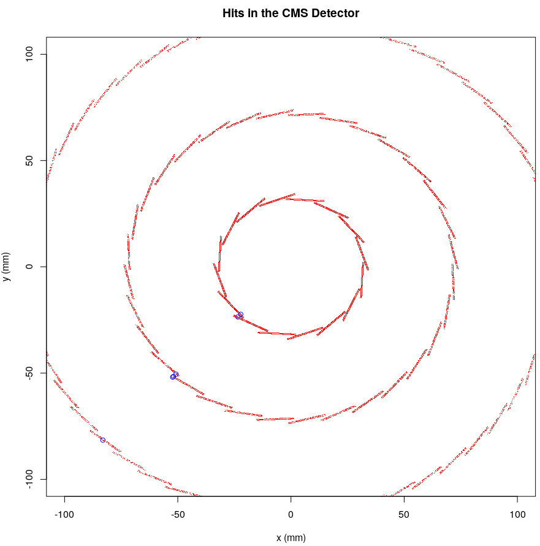

## Plotting all hits in X-Y plane (IV)

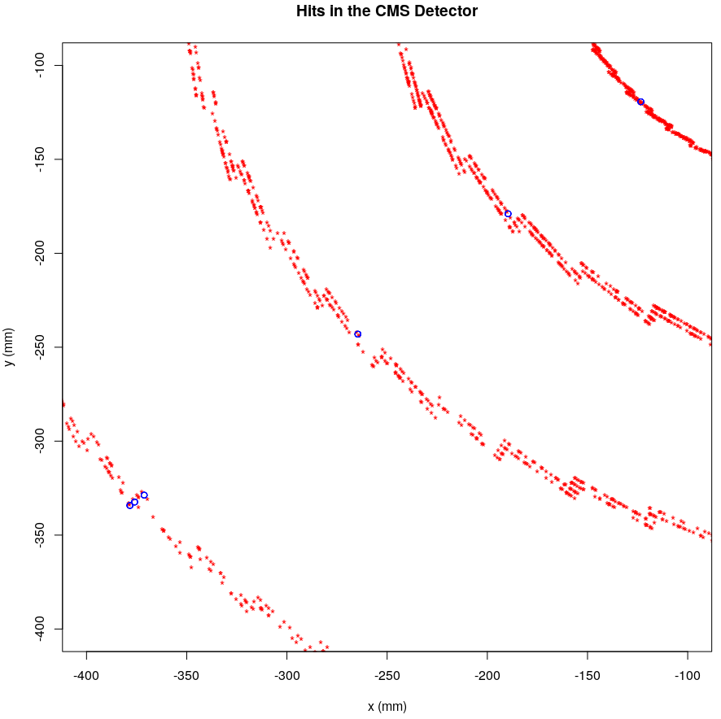

## Plotting all hits in Z-Y plane

- And the same happens in Z-Y (or Z-X) plane
- So let's try to remove duplicated events

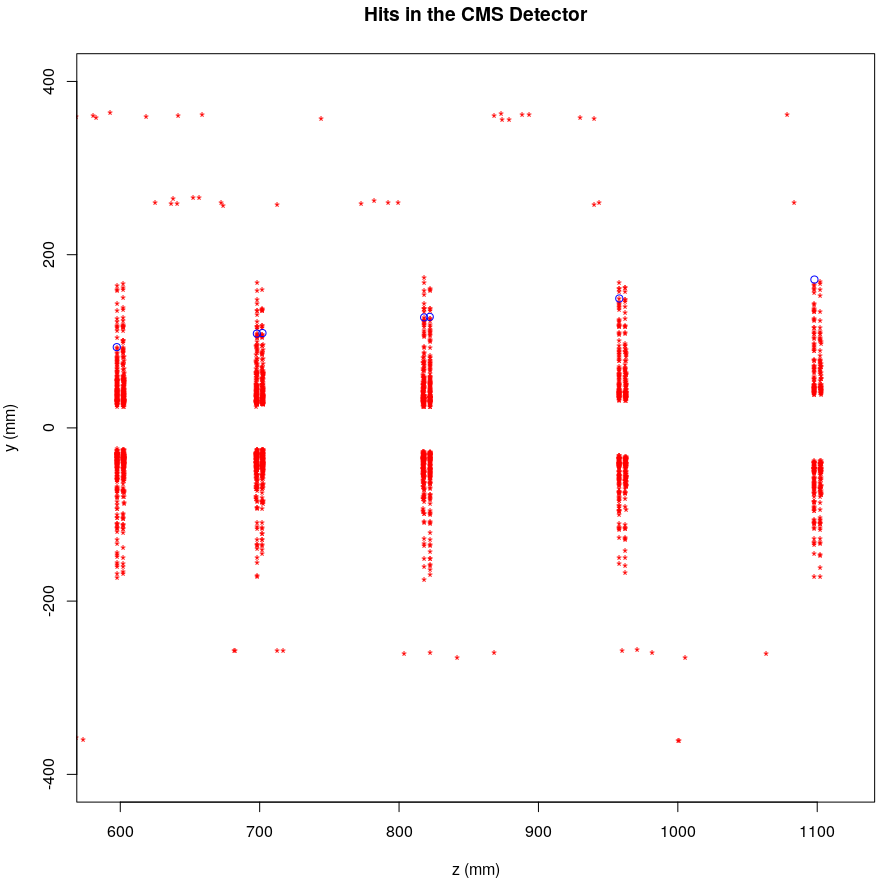

## Let's clean up the data set

## Method to clean up the data set (I)

- Compute 3D distance between each 2 subsequent hits
  - in the same track

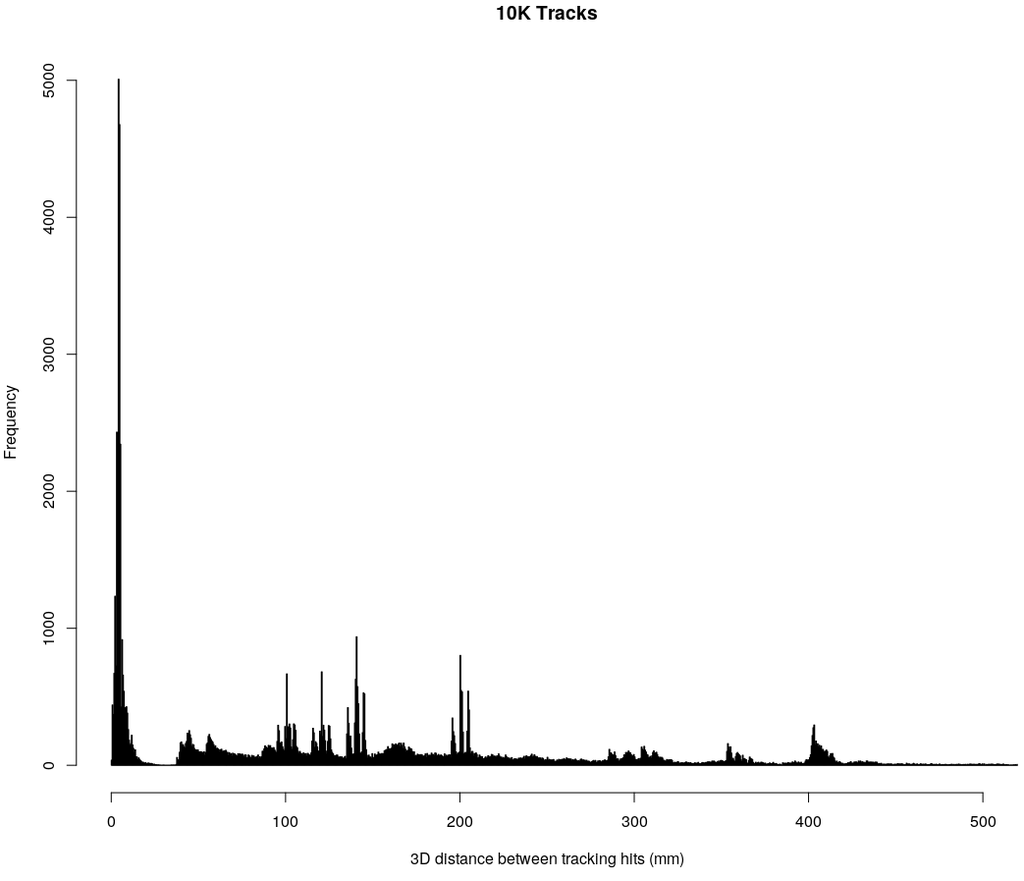

## Method to clean up the data set (II)

- Looking closer
  - A pick for 3D distance < 20 mm seems to be due duplicated hits in the same layer

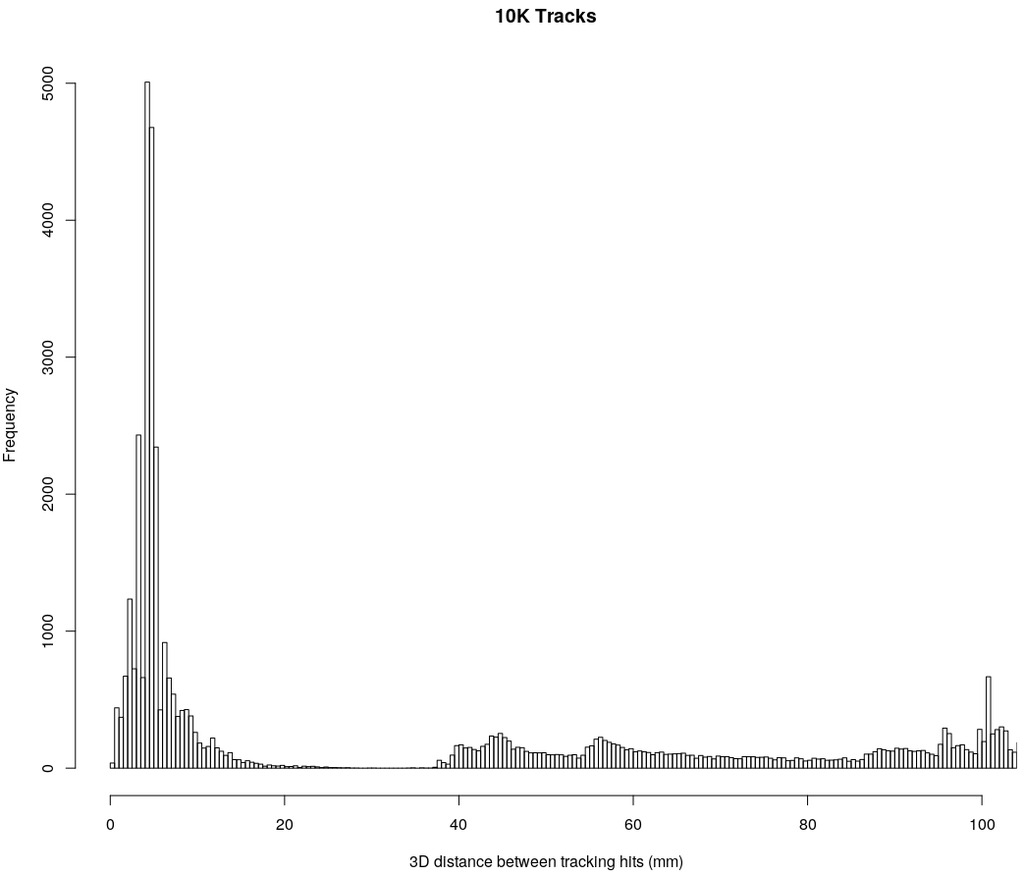

## Method to clean up the data set (III)

- Looking even closer
  - Shoud we consider a tighter cut?

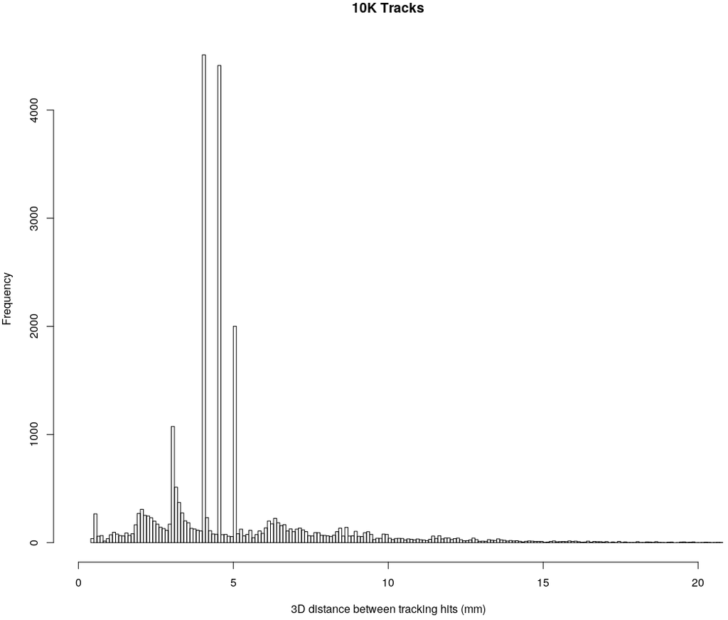

## A cut of 20 mm is reasonable?

- Looking the central region of the detector
  - Distance between plates seems to be higher than 20 mm
  - So a cut in 20 mm looks fine

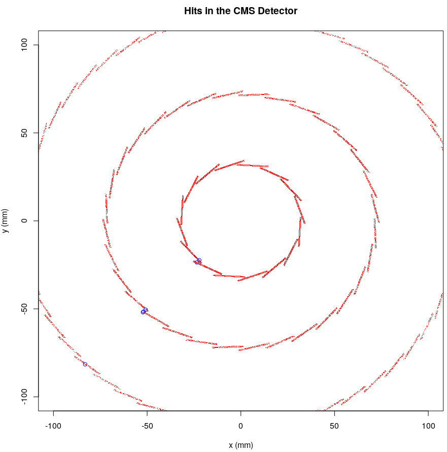

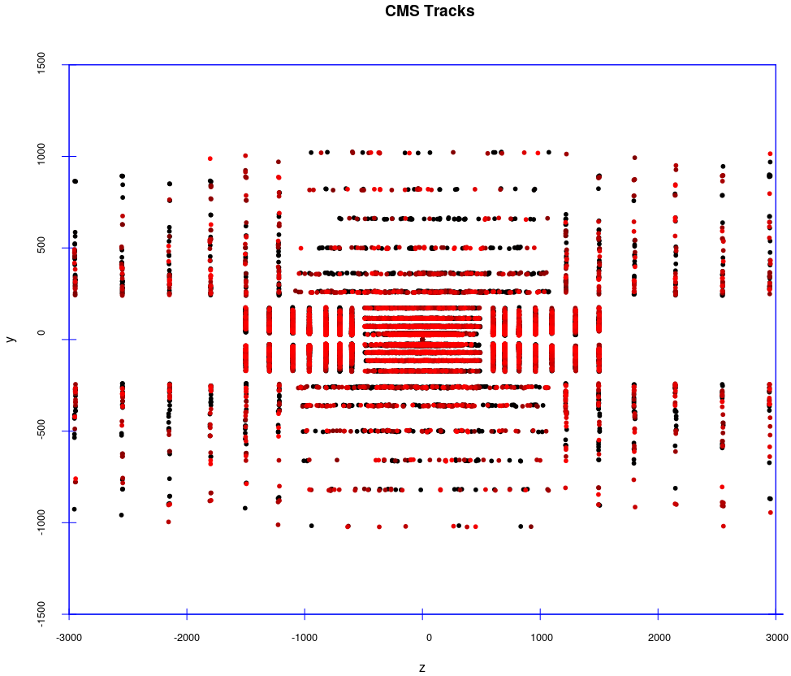

## Comparing tracks after clean up (X-Y)

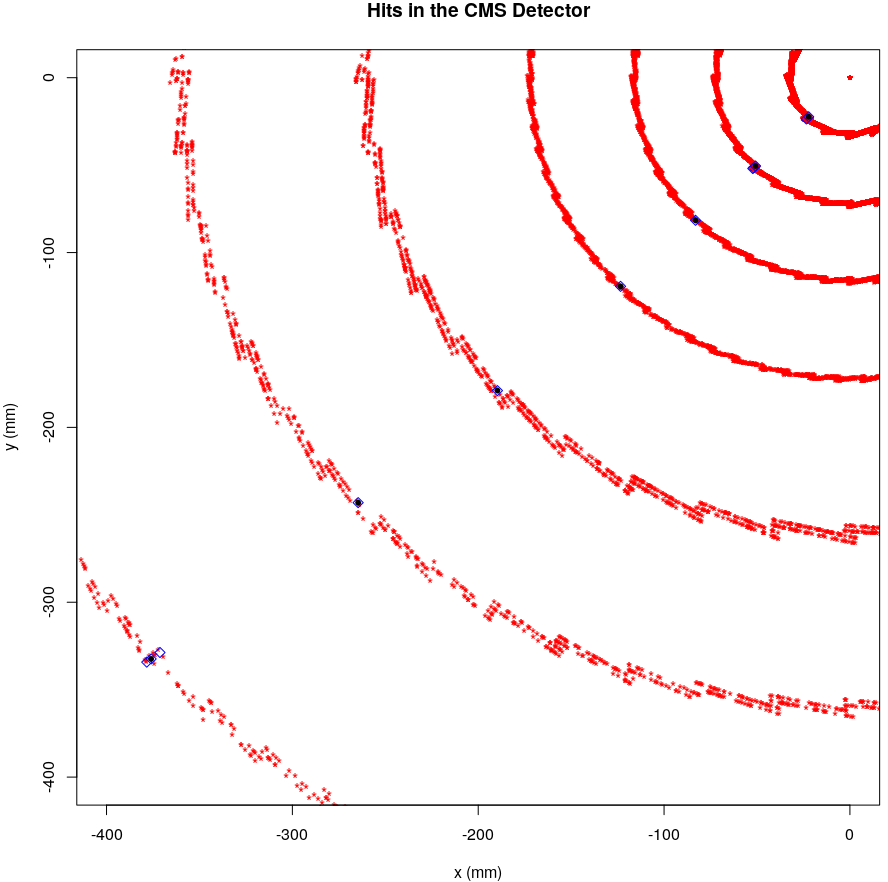

## Comparing tracks after clean up (Z-Y)

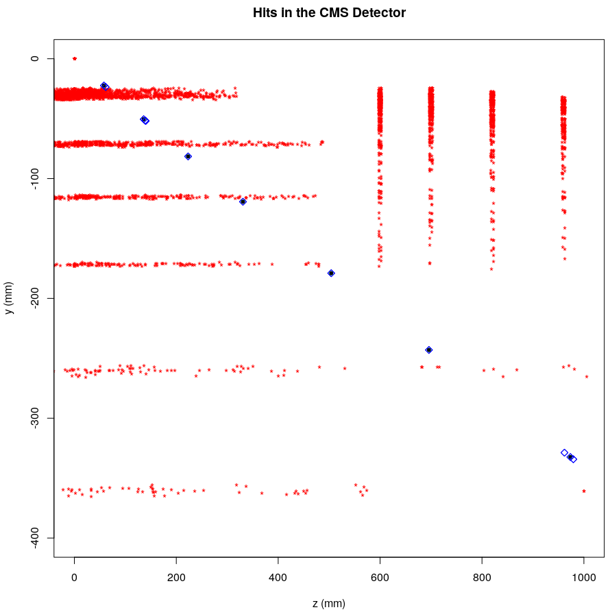

## Predicted results after clean up (I)

- What about the horizontal points in a straight line?
- Does it seem reasonable? Actually it is pure Physics!!!

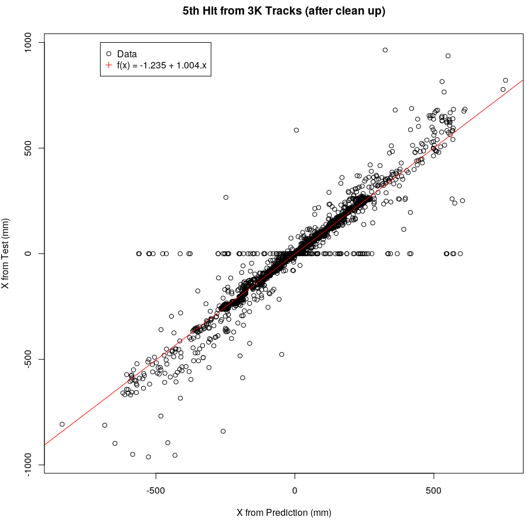

## Predicted results after clean up (II)

- It seems GBM has learned Physics
  - finding a 5th hit even when there is no hit

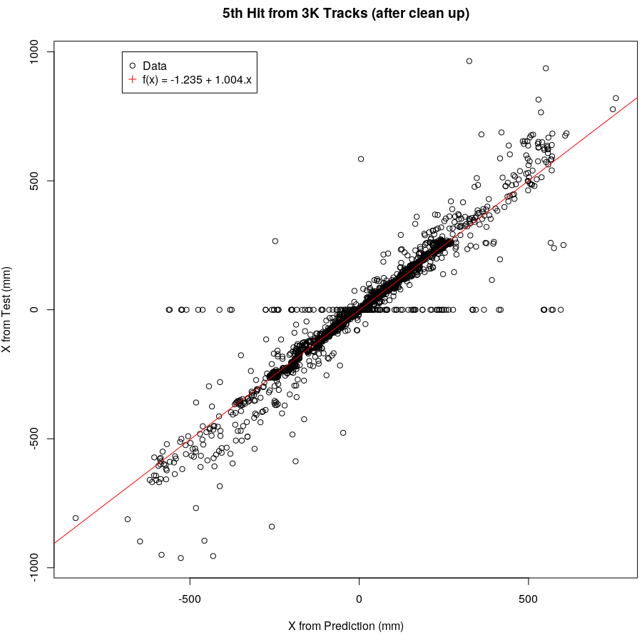

## Predicted results after clean up (III)

- Now for Y and Z predictions
- Results are not satisfied for Z, needing more studies

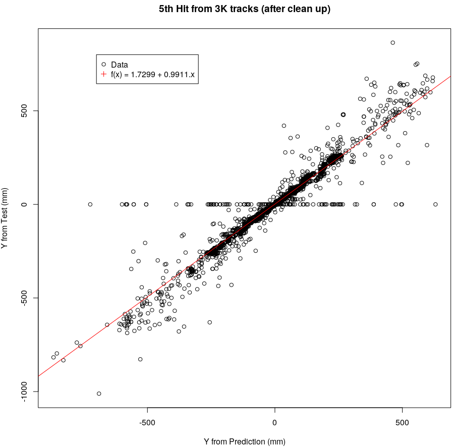

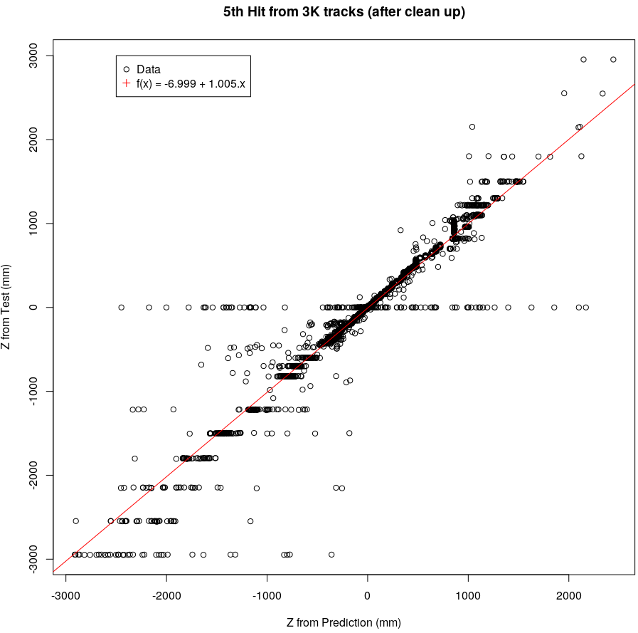

## Next Steps

## To-Do-List

- Tune GBM parameters
- Try to predict all the other hits in the track
- Find nearest neighbor point of a predicted point

## Moving ahead

## Tune GBM parameters

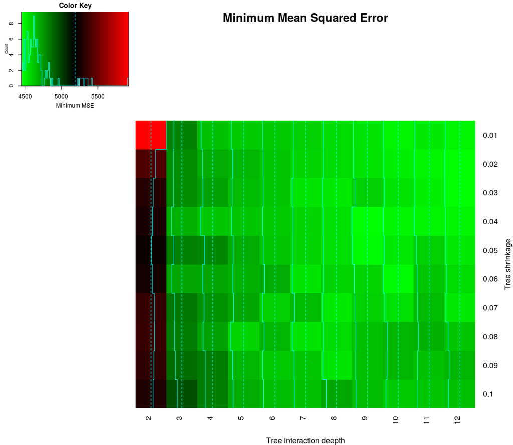

## Clustering heat map cells

- Unfortunately, Minimum MSE = 4454 mm\(^2\)
  - which corresponds to 6.6 cm (error too big!!!)

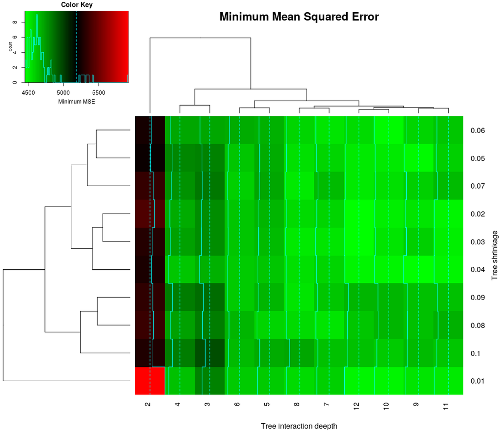

## New idea: cutting out parameters (I)

- Let's try to predict a 4th point from previous 3 ones
- Minimum MSE = 2122 mm\(^2\) (4.6 cm)

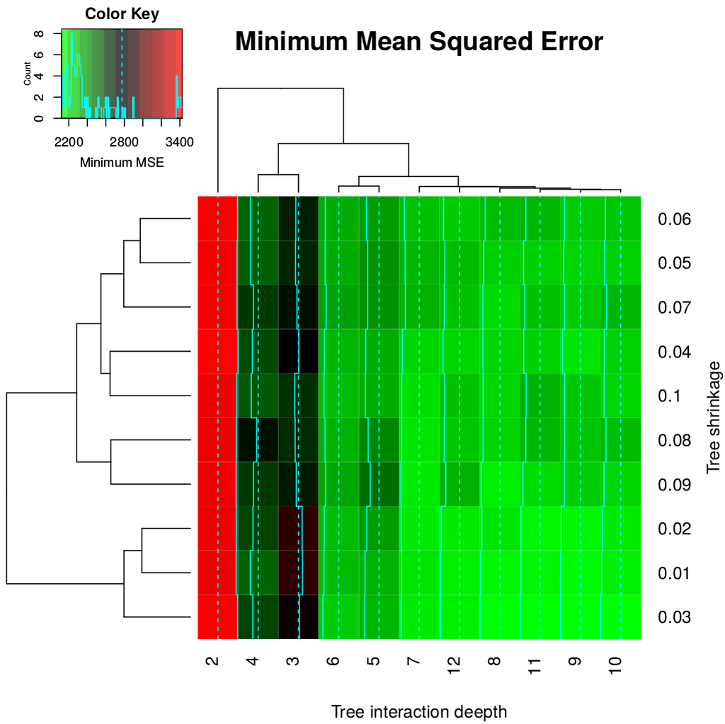

## New idea: cutting out parameters (II)

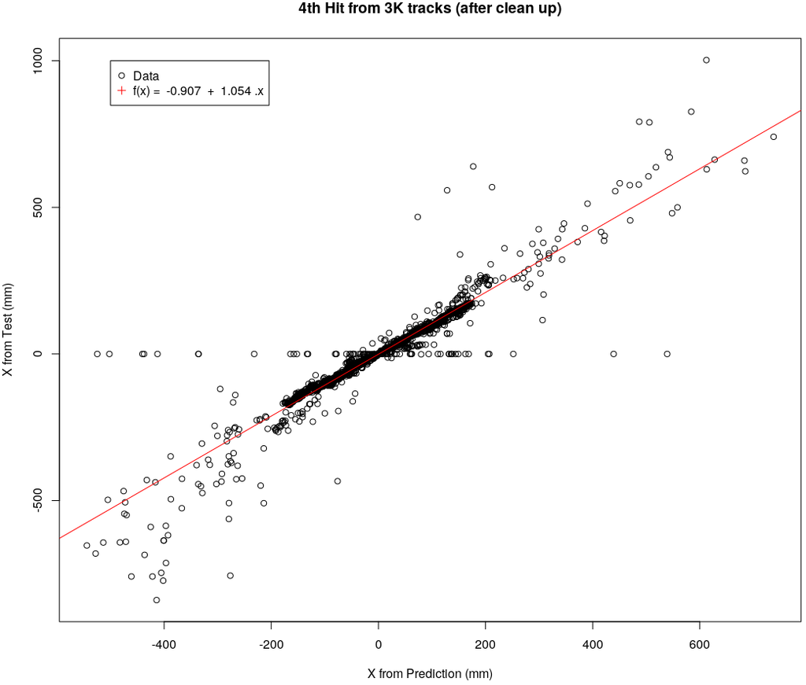

## Next steps (finally)

- Counting out more parameters
- Try to predict all the other hits in the track
- Find nearest neighbor point of a predicted point